# Mini Projeto - Análise Financeira com Linguagem SQL e Regressão Linear

Gabriel Bueno

2022-09-12

# Análise Exploratória com SQL

Este é um código feito por Gabriel Bueno Guimarães como um projeto proposto ao curso 1 de R com Microsoft Azure da Formação Cientista de Dados da Data Science Academy

**Problema:** Uma rede de hospitais gostaria de compreender as variáveis relacionadas aos gastos com internações hospitalares de pacientes.

**Dicionário de dados:**

- *Age*: Idade do paciente;
- *Female:* Variável binária que indica se o paciente é do sexo feminino;
- *LOS*: Tempo de internação do paciente;
- *RACE*: Raça do paciente;
- *TOTCHG*: Custo de internação
- *APRDG*: Grupo de diagnóstico refinado do paciente

```r
df <- read_csv('dataset.csv')
# Head do dataset
head(df)
```

```
## # A tibble: 6 × 6
##     AGE FEMALE   LOS  RACE TOTCHG APRDRG
##   <dbl>  <dbl> <dbl> <dbl>  <dbl>  <dbl>
## 1    17      1     2     1   2660    560
## 2    17      0     2     1   1689    753
## 3    17      1     7     1  20060    930
## 4    17      1     1     1    736    758
## 5    17      1     1     1   1194    754
## 6    17      0     0     1   3305    347
```

Verificando como são os dados do dataset.

```r
str(df)
```

```
## spec_tbl_df [500 × 6] (S3: spec_tbl_df/tbl_df/tbl/data.frame)
##  $ AGE   : num [1:500] 17 17 17 17 17 17 17 16 16 17 ...
##  $ FEMALE: num [1:500] 1 0 1 1 1 0 1 1 1 1 ...
##  $ LOS   : num [1:500] 2 2 7 1 1 0 4 2 1 2 ...
##  $ RACE  : num [1:500] 1 1 1 1 1 1 1 1 1 1 ...
##  $ TOTCHG: num [1:500] 2660 1689 20060 736 1194 ...
##  $ APRDRG: num [1:500] 560 753 930 758 754 347 754 754 753 758 ...
##  - attr(*, "spec")=
##   .. cols(
##   ..   AGE = col_double(),
##   ..   FEMALE = col_double(),
##   ..   LOS = col_double(),
##   ..   RACE = col_double(),
##   ..   TOTCHG = col_double(),
##   ..   APRDRG = col_double()
##   .. )
##  - attr(*, "problems")=<externalptr>
```

Analisando os valores ausentes no dataset, tem-se:

```r
sapply(df, function(x) sum(is.na(x)))
```

```
##    AGE FEMALE    LOS   RACE TOTCHG APRDRG
##      0      0      0      1      0      0
```

Pela análise exploratória inicial, só existe um valor ausente e ele está presente na coluna RACE, portanto, vamos retirar este valor ausente do conjunto de dados.

```r
df <- na.omit(df)
```

## Respondendo às perguntas de negócio

### **Pergunta 1:** Quantas raças estão representadas no dataset?

```r
sqldf('SELECT RACE as Raças,
      COUNT(RACE) as Num_Raças
      FROM df')
```

```
##   Raças Num_Raças
## 1     1       499
```

### **Pergunta 2:** Qual a idade média dos pacientes?

```r
sqldf('SELECT AVG(AGE) as Media_Idades FROM df')
```

```
##   Media_Idades
## 1     5.096192
```

A idade média dos pacientes é de **5.1**.

### **Pergunta 3:** Qual a moda da idade dos pacientes?

```r
sqldf('SELECT MODE(AGE) as Moda_Idades,
      COUNT(*) as Quantidade from df
      GROUP BY AGE')
```

```
##    Moda_Idades Quantidade
## 1            0        306
## 2            1         10
## 3            2          1
## 4            3          3
## 5            4          2
## 6            5          2
## 7            6          2
## 8            7          3
## 9            8          2
## 10           9          2
## 11          10          4
## 12          11          8
## 13          12         15
## 14          13         18
## 15          14         25
## 16          15         29
## 17          16         29
## 18          17         38
```

Com isso, é possível observar que **0** é a idade mais comum dos pacientes internados, o que faz sentido uma vez que bebês tendem a ir mais frequentemente a hospitais ou até mesmo internações de nascimentos pré maturos ou outras complicações médicas.

### **Pergunta 4:** Qual a variância da coluna idade?

```r
sqldf('SELECT VARIANCE(AGE) as Variancia_Idade FROM df')
```

```
##   Variancia_Idade
## 1        48.34013
```

A variância representa uma medida de dispersão que indica a distância de cada valor de uma determinada base de dados em relação a sua média. A variância representa o quadrado do desvio padrão, sendo a variância um pouco menos interpretável ao cerébro humano que o desvio padrão.

### **Pergunta 5:** Qual o gasto total de internações por idade?

```r
sqldf('SELECT AGE, SUM(TOTCHG) as Total_Gasto_Idade from df
      GROUP BY AGE
      ORDER BY Total_Gasto_Idade DESC')
```

```
##    AGE Total_Gasto_Idade
## 1    0            676962
## 2   17            174777
## 3   15            111747
## 4   16             69149
## 5   14             64643
## 6   12             54912
## 7    1             37744
## 8   13             31135
## 9    3             30550
## 10  10             24469
## 11   9             21147
## 12   5             18507
## 13   6             17928
## 14   4             15992
## 15  11             14250
## 16   7             10087
## 17   2              7298
## 18   8              4741
```

### **Pergunta 6:** Qual a idade gera o maior gasto com internações hospitalares?

Do resultado obtido na pergunta 5, é possível notar que os pacientes que mais gastam são os pacientes com 0 anos de idade seguido pelos pacientes de 17 e 15 anos.

### **Pergunta 7:** Qual o gasto total com internações hospitalares por genêro?

```r
sqldf('SELECT FEMALE as Sexo_Feminino,
      SUM(TOTCHG) as Gasto_Total  FROM df
      GROUP BY FEMALE')
```

```
##   Sexo_Feminino Gasto_Total
## 1             0      735391
## 2             1      650647
```

Com esse resultado do código acima, pode-se perceber que os homens tendem a ter gastos maiores com internação.

### **Pergunta 8:** Qual a média de gasto com internações hospitalares por raça do paciente?

```r
sqldf('SELECT RACE as Raça, AVG(TOTCHG) as Gasto_Medio
      FROM df
      GROUP BY RACE
      ORDER BY Gasto_Medio DESC')
```

```
##   Raça Gasto_Medio
## 1    2    4202.167
## 2    3    3041.000
## 3    1    2772.669
## 4    4    2344.667
## 5    5    2026.667
## 6    6    1349.000
```

A saída do código acima mostra o **gasto médio** de internação por raça, onde é possível perceber que a raça 2 possui o maior gasto médio dentre todas as outras raças

### **Pergunta 9:** Para pacientes acima de 10 anos, qual a média de gasto total com internações hospitalares?

```r
sqldf('SELECT AGE as Idade,
        AVG(TOTCHG) as Media_Gastos from df
        WHERE AGE > 10
        GROUP BY AGE')
```

```
##   Idade Media_Gastos
## 1    11     1781.250
## 2    12     3660.800
## 3    13     1729.722
## 4    14     2585.720
## 5    15     3853.345
## 6    16     2384.448
## 7    17     4599.395
```

### **Pergunta 10:** Considerando o item anterior, qual idade tem média de gastos superior a 3000?

```r
sqldf('SELECT AGE as Idade,
      AVG(TOTCHG) as Media_Gastos from df
      WHERE AGE > 10
      GROUP BY AGE
      HAVING Media_Gastos > 3000
      ORDER BY Media_Gastos DESC')
```

```
##   Idade Media_Gastos
## 1    17     4599.395
## 2    15     3853.345
## 3    12     3660.800
```

# Análise de Regressão

### **Pergunta 1:** Qual a distribuição de idade dos pacientes que frequentam o hospital?

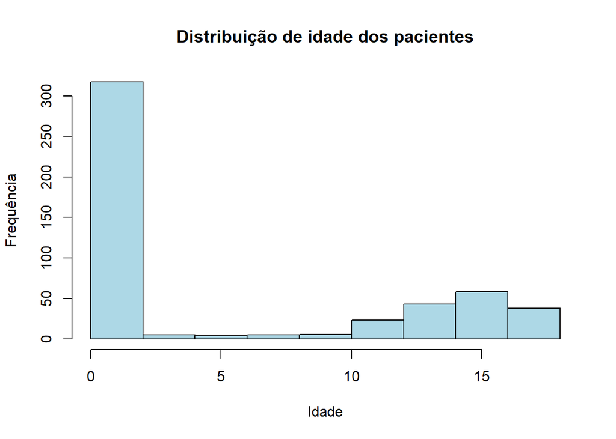

```r
hist(df$AGE,
     main = 'Distribuição de idade dos pacientes',
     xlab = 'Idade',
     ylab = 'Frequência',
     col = 'lightblue'
     )
```

Pelo histograma, é possível perceber que crianças com 0 anos de idade são os mais comuns na ala de internação daquele hospital.

### **Pergunta 2:** Qual faixa etária tem o maior gasto total no hospital?

Agrupando os dados associado a idade com o gasto total.

```r
faixa_etaria <- df %>%
  select(AGE, TOTCHG) %>%
  group_by(AGE) %>%
  summarise(gasto_total = sum(TOTCHG))
faixa_etaria
```

```
## # A tibble: 18 × 2
##      AGE gasto_total
##    <dbl>       <dbl>
##  1     0      676962
##  2     1       37744
##  3     2        7298
##  4     3       30550
##  5     4       15992
##  6     5       18507
##  7     6       17928
##  8     7       10087
##  9     8        4741
## 10     9       21147
## 11    10       24469
## 12    11       14250
## 13    12       54912
## 14    13       31135
## 15    14       64643
## 16    15      111747
## 17    16       69149
## 18    17      174777
```

Plotando o gráfico que mostra a faixa etária que mais gasta com internações.

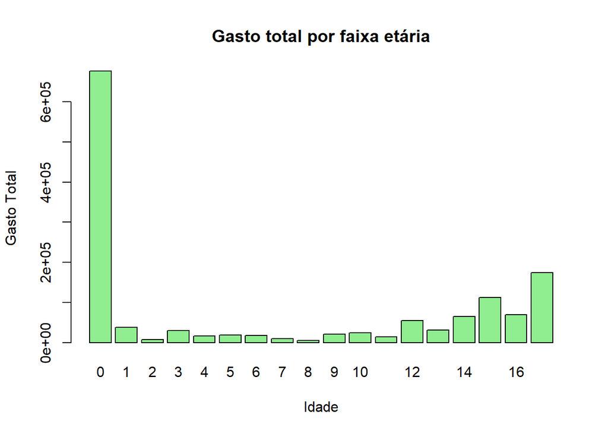

```r
barplot(height = faixa_etaria$gasto_total,
        names.arg = faixa_etaria$AGE,
        xlab = 'Idade',
        ylab = 'Gasto Total',
        main = 'Gasto total por faixa etária',
        col = 'lightgreen')
```

Pode-se dizer que a faixa etária que possui maior gasto é de [0-1) anos de idade.

### **Pergunta 3:** Qual grupo baseado em diagnóstico (Aprdrg) tem o maior gasto total no hospital?

Agregando os dados e organizando os resultados obtidos do maior para o menor valor de gasto total com internação.

```r
grupo_diagnostico <- aggregate(TOTCHG ~ APRDRG ,
                               data = df,
                               FUN = sum) %>%
                    arrange(desc(TOTCHG))
grupo_diagnostico
```

```
##    APRDRG TOTCHG
## 1     640 436822
## 2      53  82271
## 3     753  79542
## 4     754  59150
## 5     911  48388
## 6     758  34953
## 7     602  29188
## 8     614  27531
## 9     930  26654
## 10    421  26356
## 11    115  25832
## 12    225  25649
## 13    626  23289
## 14    636  23224
```

[output cut: 49 more lines]

Isso nos mostra que o grupo de diagnótico **640** é o grupo que mais gasta com internações.

### **Pergunta 4:** A raça dos pacientes tem relação com o total gasto em internações no hospital?

Usando uma regressão linear para confirmar a hipótese.

H0: Não há efeito de RACE em TOTCH

HA: Há efeito de RACE em TOTCH

```r
modelo.v1 <- lm(TOTCHG ~ RACE, data = df)
summary(modelo.v1)
```

```
##
## Call:
## lm(formula = TOTCHG ~ RACE, data = df)
##
## Residuals:
##    Min     1Q Median     3Q    Max
##  -2256  -1560  -1227   -258  45600
##
## Coefficients:
##             Estimate Std. Error t value Pr(>|t|)
## (Intercept)   2925.7      405.0   7.224 1.92e-12 ***
## RACE          -137.3      339.1  -0.405    0.686
## ---
## Signif. codes:  0 '***' 0.001 '**' 0.01 '*' 0.05 '.' 0.1 ' ' 1
##
## Residual standard error: 3895 on 497 degrees of freedom
## Multiple R-squared:  0.0003299,  Adjusted R-squared:  -0.001681
## F-statistic: 0.164 on 1 and 497 DF,  p-value: 0.6856
```

Como Pr(>| t | ) > 0.05 para todos os casos, não há evidência estatística suficiente para rejeitar H0, portatanto, provavelmente não há um efeito de RACE em TOTCH.

### **Pergunta 5:** A combinação de idade e genêro influencia no gasto total de internações do hospital?

Realizando mais uma regressão linear.

Suposições:

H0: Não há efeito de AGE e FEMALE em TOTCHG

HA: Há efeito de AGE e FEMALE em TOTCHG

```r
modelo.v2 <- lm(TOTCHG ~AGE + FEMALE, data = df)
summary(modelo.v2)
```

```
##
## Call:
## lm(formula = TOTCHG ~ AGE + FEMALE, data = df)
##
## Residuals:
##    Min     1Q Median     3Q    Max
##  -3403  -1444   -873   -156  44950
##
## Coefficients:
##             Estimate Std. Error t value Pr(>|t|)
## (Intercept)  2719.45     261.42  10.403  < 2e-16 ***
## AGE            86.04      25.53   3.371 0.000808 ***
## FEMALE       -744.21     354.67  -2.098 0.036382 *
## ---
## Signif. codes:  0 '***' 0.001 '**' 0.01 '*' 0.05 '.' 0.1 ' ' 1
##
## Residual standard error: 3849 on 496 degrees of freedom
## Multiple R-squared:  0.02585,    Adjusted R-squared:  0.02192
## F-statistic: 6.581 on 2 and 496 DF,  p-value: 0.001511
```

Portanto, como Pr(>F) para ambos os casos das variáveis independentes é menor que 0.05, rejeita-se a hipótese nula. Portanto, é provável que há um efeito significativo de AGE e FEMALE em TOTCHG.

### **Pergunta 6:** Como o tempo de permanência é o fator crucial para pacientes internados, desejamos descobrir se o tempo de permanência pode ser previsto a partir de idade, genêro e raça.

Aplicando mais uma regressão linear para verificar se é possível prever o tempo de permanência.

Hipóteses:

- H0: Não é possível prever o tempo de permanência com a idade, genêro e raça. (Não há uma relação linear)
- HA: É possível prever o tempo de permanência com a idade, genêro e raça.

```r
modelo.v3 <- lm(LOS ~ AGE + FEMALE + RACE, data = df)
summary(modelo.v3)
```

```
##
## Call:
## lm(formula = LOS ~ AGE + FEMALE + RACE, data = df)
##
## Residuals:
##    Min     1Q Median     3Q    Max
##  -3.22  -1.22  -0.85   0.15  37.78
##
## Coefficients:
##             Estimate Std. Error t value Pr(>|t|)
## (Intercept)  2.94377    0.39318   7.487 3.25e-13 ***
## AGE         -0.03960    0.02231  -1.775   0.0766 .
## FEMALE       0.37011    0.31024   1.193   0.2334
## RACE        -0.09408    0.29312  -0.321   0.7484
## ---
## Signif. codes:  0 '***' 0.001 '**' 0.01 '*' 0.05 '.' 0.1 ' ' 1
##
## Residual standard error: 3.363 on 495 degrees of freedom
## Multiple R-squared:  0.007898,   Adjusted R-squared:  0.001886
## F-statistic: 1.314 on 3 and 495 DF,  p-value: 0.2692
```

Como o valor de Pr(> | t |) é maior que 0.05 em todos os casos, falhamos em rejeitar H0. Provavelmente, não é possível prever a internação somente com a idade, genêro e a raça, pois não há uma relação linear entre elas.

### **Pergunta 7:** Qual variável tem maior impacto nos custos de internação hospitalar?

Fazendo um modelo de regressão linear e depois analisando as estatísticas de cada uma das variáveis.

```r
modelo.v4 <- lm(TOTCHG ~ . , data =df)
summary(modelo.v4)
```

```
##
## Call:
## lm(formula = TOTCHG ~ ., data = df)
##
## Residuals:
##    Min     1Q Median     3Q    Max
##  -6377   -700   -174    122  43378
##
## Coefficients:
##              Estimate Std. Error t value Pr(>|t|)
## (Intercept) 5218.6769   507.6475  10.280  < 2e-16 ***
## AGE          134.6949    17.4711   7.710 7.02e-14 ***
## FEMALE      -390.6924   247.7390  -1.577    0.115
## LOS          743.1521    34.9225  21.280  < 2e-16 ***
## RACE        -212.4291   227.9326  -0.932    0.352
## APRDRG        -7.7909     0.6816 -11.430  < 2e-16 ***
## ---
## Signif. codes:  0 '***' 0.001 '**' 0.01 '*' 0.05 '.' 0.1 ' ' 1
##
## Residual standard error: 2613 on 493 degrees of freedom
## Multiple R-squared:  0.5536, Adjusted R-squared:  0.5491
## F-statistic: 122.3 on 5 and 493 DF,  p-value: < 2.2e-16
```

Obteve-se um **R<sup>2</sup> = 0.5491**. Como o nível de significancia para as variáveis **RACE** e **FEMALE** não ajudam na previsão, remove-se ambas.

```r
modelo.v5 <- lm(TOTCHG ~ AGE +  LOS + APRDRG , data = df)
summary(modelo.v5)
```

```
##
## Call:
## lm(formula = TOTCHG ~ AGE + LOS + APRDRG, data = df)
##
## Residuals:
##    Min     1Q Median     3Q    Max
##  -6603   -719   -169    124  43350
##
## Coefficients:
##              Estimate Std. Error t value Pr(>|t|)
## (Intercept) 4960.1705   433.6579   11.44  < 2e-16 ***
## AGE          128.5519    17.0946    7.52 2.59e-13 ***
## LOS          740.8057    34.9161   21.22  < 2e-16 ***
## APRDRG        -8.0055     0.6643  -12.05  < 2e-16 ***
## ---
## Signif. codes:  0 '***' 0.001 '**' 0.01 '*' 0.05 '.' 0.1 ' ' 1
##
## Residual standard error: 2617 on 495 degrees of freedom
## Multiple R-squared:  0.5506, Adjusted R-squared:  0.5479
## F-statistic: 202.2 on 3 and 495 DF,  p-value: < 2.2e-16
```

Portanto, as variáveis **AGE, LOS, APRDRG** são as variáveis que mais impactam nos valores da internação hospitalar.